# Business-Day Scaling

Dave Mills

2016-03-16

When graphing financial data, I prefer a continuous axis scale where weekends and holidays don’t exist. Did the price remain unchanged for three days, or am I looking at labor-day weekend?

## Create sample data

Load past NYSE trading dates, taken from Yahoo’s S&P prices:

```r
data(nyse)
```

Then create some fake prices, put them into a `data.frame` alongside the dates:

```r
set.seed(12345)
df <- data.frame(date=nyse, price=cumsum(rnorm(length(nyse))) + 100)
df <- subset(df, as.Date('2014-08-01') <= date & date <= as.Date('2014-10-08'))
```

|  | date | price |
| --- | --- | --- |
| 16293 | 2014-10-02 | 87.78927 |
| 16294 | 2014-10-03 | 88.20406 |
| 16295 | 2014-10-06 | 88.13665 |
| 16296 | 2014-10-07 | 88.46860 |
| 16297 | 2014-10-08 | 88.81567 |

## Plot on a standard calendar-day axis:

Create a plot:

```r
plot <- ggplot(df, aes(x=date, y=price)) + geom_step() +
  theme(axis.title.x=element_blank(), axis.title.y=element_blank())
```

Note the large gap at the beginning of September, because Labor Day was on the 1st:

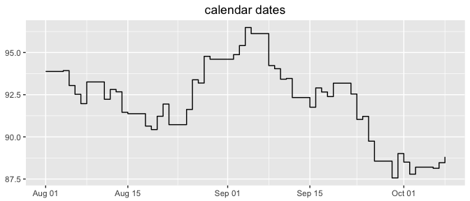

```r
plot + ggtitle('calendar dates')
```

## Plot on a business-day axis:

Plotting against `scale_x_bd` instead removes weekends and holidays from the graph:

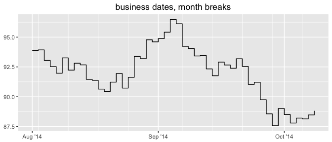

```r
plot + scale_x_bd(business.dates=nyse, labels=date_format("%b '%y")) +
  ggtitle('business dates, month breaks')
```

## Increasing density of breaks

In the previous chart, the major breaks are pretty far apart.

The package determined that breaks on the first trading day of each **month** gives me the largest number of breaks weakly less than maximum. I didn’t specify a max, so it defaulted to `5`.

If I tell it to use more, it can put breaks on the first day of each **week**:

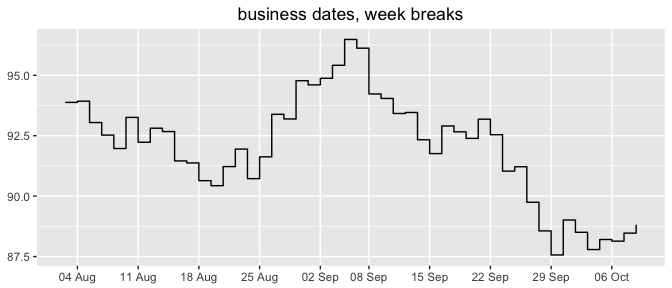

```r
plot + scale_x_bd(business.dates=nyse, max.major.breaks=10, labels=date_format('%d %b')) +
  ggtitle('business dates, week breaks')
```

## Translating into business-day space

Say I wanted to put vertical lines on option expiration dates.

Calling `as.numeric(...)` on my dates translates them into the the number of calendar days after unix epoch, which is what `scale_x_date(...)` uses (see `scales:::from_date`):

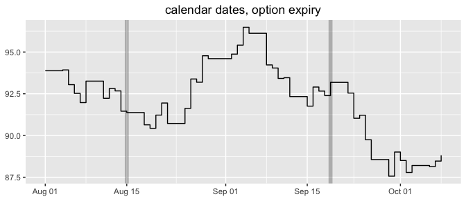

```r
options <- as.Date(c('2014-08-15', '2014-09-19'))

plot +
  geom_vline(xintercept=as.numeric(options), size=2, alpha=0.25) +
  ggtitle('calendar dates, option expiry')
```

This doesn’t work for business-day space because the x-axis now represents the number of business days after the first date in your `business.dates` vector:

|  | `scale_x_date` | `scale_x_bd` |
| --- | --- | --- |
| origin | unix epoch: `1970-01-01` | first date in your `business.dates` vector |
| axis values | number of **calendar days** after origin | number of **business days** after origin |
| conversion | `as.numeric(...)` | `bd2t(..., business.dates)` |

Instead, use the `bdscale::bd2t(...)` function to translate into business-day space:

[figure not shown]

```r
plot +
  geom_vline(xintercept=bd2t(options, business.dates=nyse), size=2, alpha=0.25) +
  scale_x_bd(business.dates=nyse) +
  ggtitle('business dates, option expiry')
```